# COMPSCIX 415.2 Homework 2

Chunduri SriKeerthi Chandra

Jun 19th 2018

## **Data Visualisation using ggplot2**

### 3.2.4 Exercises

*Q: Run ggplot(data = mpg). What do you see?*

ggplot() prepares the co-ordinate system for *mpg* data frame. It doesn’t plot any geomentric data to show the raw data contained in the data frame.

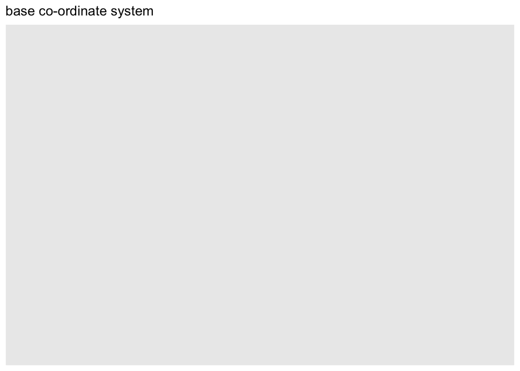

```r
ggplot(data=mpg) + ggtitle('base co-ordinate system')
```

**Q:** How many rows are in mpg? How many columns?

mpg data-frame captures has **11** variables and **234** observations.

**Q:** What does the drv variable describe? Read the help for ?mpg to find out.

**drv** variable describes the drivetrain of a car, it is the set of components that deliver power to the wheels. **drv** is a categorical variable with values  
1. f= front-wheel drive 2. r = rear wheel drive 3. 4 = 4wd

**Q:** Make a scatterplot of hwy vs cyl

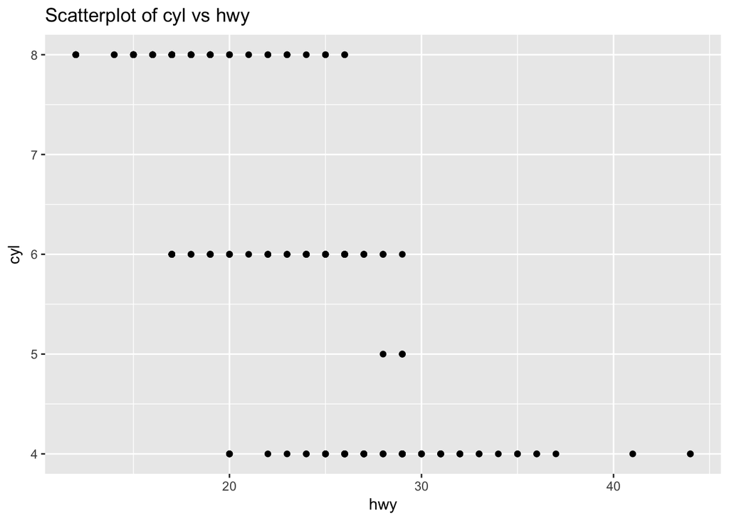

```r
ggplot(data = mpg) + geom_point(mapping = aes(x = hwy, y = cyl)) + labs(title = "Scatterplot of cyl vs hwy")
```

The scatterplot of hwy vs cyl shows that they are inversely proportional.

**Q:** What happens if you make a scatterplot of class vs drv? Why is the plot not useful?

Both vehicle class and drivetrain are categorical variables and hence doesn’t give much insight.

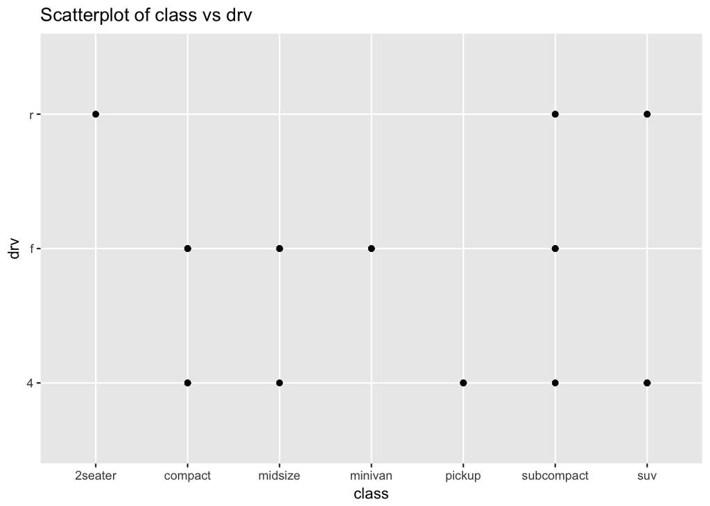

```r
ggplot(data = mpg) + geom_point(mapping = aes(x = class, y = drv)) + labs(title = "Scatterplot of class vs drv")
```